AFRICAST

Tidy time series & forecasting in R

# ARIMA models

Session 6 of 10

workshop.f4sg.org/africastForecasting for Social Good

## Outline

- ARIMA models
- Seasonal ARIMA models
- Forecast ensembles

# ARIMA models

## ARIMA models

| **AR**: | autoregressive (lagged observations as inputs) |
| --- | --- |
| **I**: | integrated (differencing to make series stationary) |
| **MA**: | moving average (lagged errors as inputs) |

An ARIMA model is rarely interpretable in terms of visible data structures like trend and seasonality. But it can capture a huge range of time series patterns.

## Stationarity

**Definition**

If $\{y_t\}$ is a stationary time series, then for all $s$, the distribution of $(y_t,\dots,y_{t+s})$ does not depend on $t$.

A **stationary series** is:

- roughly horizontal
- constant variance
- no patterns predictable in the long-term

## Stationary?

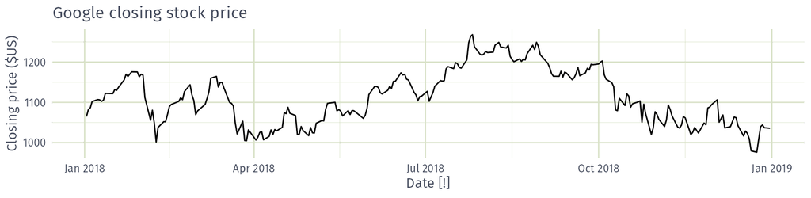

- Yes
- No

## Stationary?

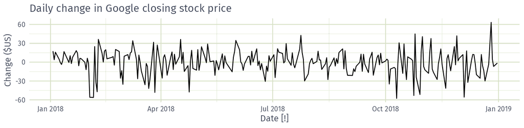

- Yes
- No

## Differencing

- Differencing helps to **stabilise the mean**.
- The differenced series is the *change* between each observation in the original series.
- Occasionally the differenced data will not appear stationary and it may be necessary to difference the data a second time.
- In practice, it is almost never necessary to go beyond second-order differences.

## Autoregressive models

**Autoregressive (AR) models:**

$$y_{t} = c + \phi_{1}y_{t - 1} + \phi_{2}y_{t - 2} + \cdots + \phi_{p}y_{t - p} + \varepsilon_{t},$$
where $\varepsilon_t$ is white noise. A multiple regression with **lagged values** of $y_t$ as predictors.

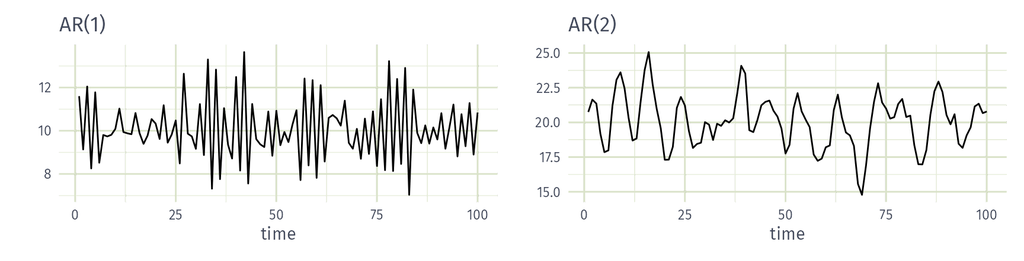

- Cyclic behaviour is possible when $p\ge 2$.

## Moving Average (MA) models

**Moving Average (MA) models:**

$$y_{t} = c + \varepsilon_t + \theta_{1}\varepsilon_{t - 1} + \theta_{2}\varepsilon_{t - 2} + \cdots + \theta_{q}\varepsilon_{t - q},$$
where $\varepsilon_t$ is white noise. A multiple regression with **lagged *errors*** as predictors. *Don’t confuse with moving average smoothing!*

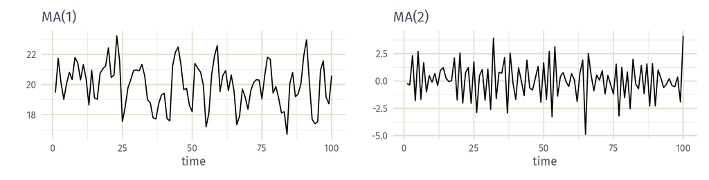

## ARIMA models

**Autoregressive Moving Average models:**

$$\begin{aligned}
y_{t} &= c + \phi_{1}y_{t - 1} + \cdots + \phi_{p}y_{t - p} \\
& \qquad + \theta_{1}\varepsilon_{t - 1} + \cdots + \theta_{q}\varepsilon_{t - q} + \varepsilon_{t}.
\end{aligned}$$

- Predictors include both **lagged values of $y_t$ and lagged errors.**

### Autoregressive Integrated Moving Average models

- Combine ARMA model with **differencing**.
- $d$-differenced series follows an ARMA model.
- Need to choose $p$, $d$, $q$ and whether or not to include $c$.

## ARIMA models

**ARIMA($p, d, q$) model**

| AR: | $p =$ order of the autoregressive part |
| --- | --- |
| I: | $d =$ degree of first differencing involved |
| MA: | $q =$ order of the moving average part. |

- White noise model: ARIMA(0,0,0)
- Random walk: ARIMA(0,1,0) with no constant
- Random walk with drift: ARIMA(0,1,0) with const.
- AR($p$): ARIMA($p$,0,0)
- MA($q$): ARIMA(0,0,$q$)

## Example: National populations

```r
fit <- global_economy |>
  model(arima = ARIMA(Population))
fit
```

```
# A mable: 263 x 2
# Key:     Country [263]
   Country                               arima
   <fct>                               <model>
 1 Afghanistan                  <ARIMA(4,2,1)>
 2 Albania                      <ARIMA(0,2,2)>
 3 Algeria                      <ARIMA(2,2,2)>
 4 American Samoa               <ARIMA(2,2,2)>
 5 Andorra             <ARIMA(2,1,2) w/ drift>
 6 Angola                       <ARIMA(4,2,1)>
 7 Antigua and Barbuda <ARIMA(2,1,2) w/ drift>
 8 Arab World                   <ARIMA(0,2,1)>
 9 Argentina                    <ARIMA(2,2,2)>
10 Armenia                      <ARIMA(3,2,0)>
# ℹ 253 more rows
```

## Example: National populations

```r
fit |>
  filter(Country == "Australia") |>
  report()
```

```
Series: Population
Model: ARIMA(0,2,1)

Coefficients:
         ma1
      -0.661
s.e.   0.107

sigma^2 estimated as 4.063e+09:  log likelihood=-699
AIC=1401   AICc=1402   BIC=1405
```

$$y_t = 2y_{t-1} - y_{t-2} - 0.7 \varepsilon_{t-1} + \varepsilon_t$$
$$\varepsilon_t \sim \text{NID}(0,4\times10^9)$$

## Understanding ARIMA models

- If $c=0$ and $d=0$, the long-term forecasts will go to zero.
- If $c=0$ and $d=1$, the long-term forecasts will go to a non-zero constant.
- If $c=0$ and $d=2$, the long-term forecasts will follow a straight line.
- If $c\ne0$ and $d=0$, the long-term forecasts will go to the mean of the data.
- If $c\ne0$ and $d=1$, the long-term forecasts will follow a straight line.
- If $c\ne0$ and $d=2$, the long-term forecasts will follow a quadratic trend.

## Understanding ARIMA models

### Forecast variance and $d$

- The higher the value of $d$, the more rapidly the prediction intervals increase in size.
- For $d=0$, the long-term forecast standard deviation will go to the standard deviation of the historical data.

## Example: National populations

```r
fit |>
  forecast(h = 10) |>
  filter(Country == "Australia") |>
  autoplot(global_economy)
```

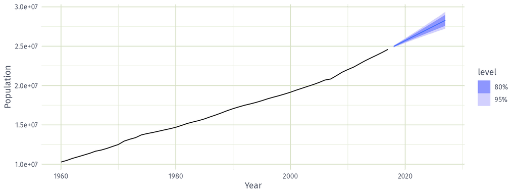

## How does ARIMA() work?

**Hyndman and Khandakar (JSS, 2008) algorithm:**

- Select no. differences $d$ via KPSS test.
- Select $p$, $q$ and inclusion of $c$ by minimising AICc.
- Use stepwise search to traverse model space.

$$\text{AICc} = -2 \log(L) + 2(p+q+k+1)\left[1 + \frac{(p+q+k+2)}{T-p-q-k-2}\right]$$
where $L$ is the maximised likelihood fitted to the *differenced* data, $k=1$ if $c\neq 0$ and $k=0$ otherwise.

Note: Can’t compare AICc for different values of $d$.

## How does ARIMA() work?

**Step 1:**

Select current model (with smallest AICc) from:  
ARIMA$(2,d,2)$, ARIMA$(0,d,0)$, ARIMA$(1,d,0)$, ARIMA$(0,d,1)$

**Step 2:**

Consider variations of current model:

- vary one of $p,q,$ from current model by $\pm1$;
- $p,q$ both vary from current model by $\pm1$;
- Include/exclude $c$ from current model.

Model with lowest AICc becomes current model.

Repeat Step 2 until no lower AICc can be found.

## How does ARIMA() work?

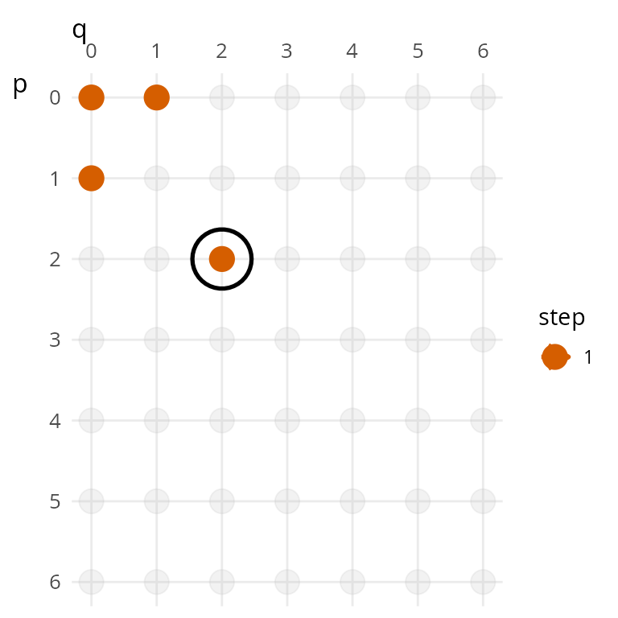

## How does ARIMA() work?

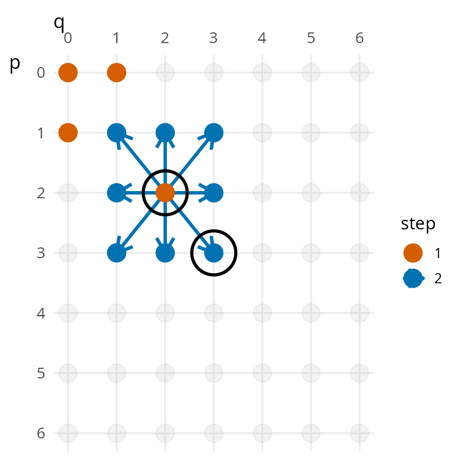

## How does ARIMA() work?

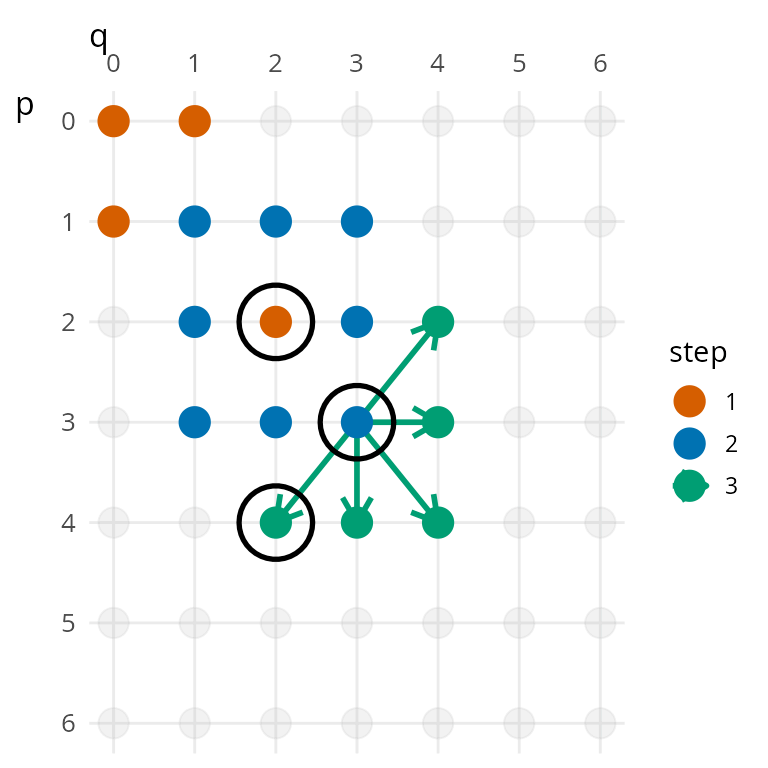

## How does ARIMA() work?

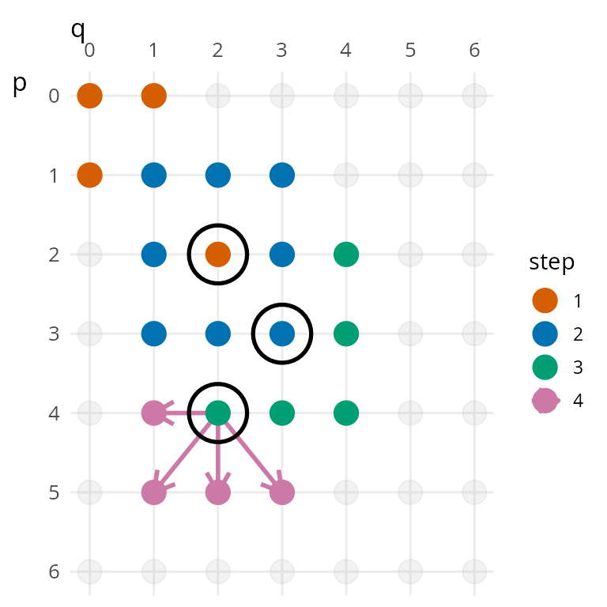

# Seasonal ARIMA models

## Seasonal ARIMA models

$$\text{ARIMA}~\underbrace{(p,d,q)}_{\text{Non-seasonal part}}~\underbrace{(P,D,Q)_m}_{\text{Seasonal part}}$$

- $m =$ number of observations per year.
- $d$ first differences, $D$ seasonal differences
- $p$ AR lags, $q$ MA lags
- $P$ seasonal AR lags, $Q$ seasonal MA lags

Seasonal and non-seasonal terms combine multiplicatively

## Corticosteroid drug sales

```r
h02 <- PBS |>
  filter(ATC2 == "H02") |>
  summarise(Cost = sum(Cost) / 1e6)
```

## Corticosteroid drug sales

```r
h02 |> autoplot(
  Cost
)
```

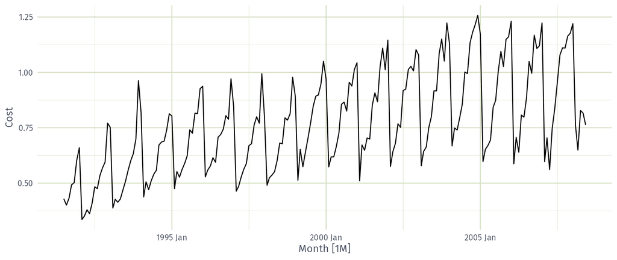

## Corticosteroid drug sales

```r
h02 |> autoplot(
  log(Cost)
)
```

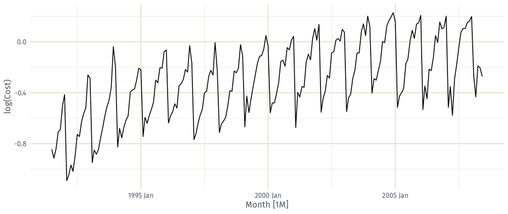

## Corticosteroid drug sales

```r
h02 |> autoplot(
  log(Cost) |> difference(12)
)
```

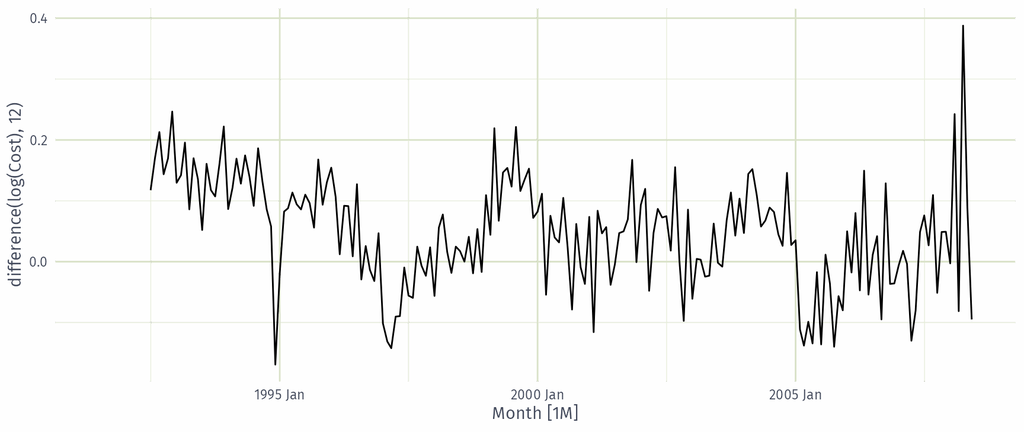

## Corticosteroid drug sales

```r
h02 |> autoplot(
  log(Cost) |> difference(12) |> difference(1)
)
```

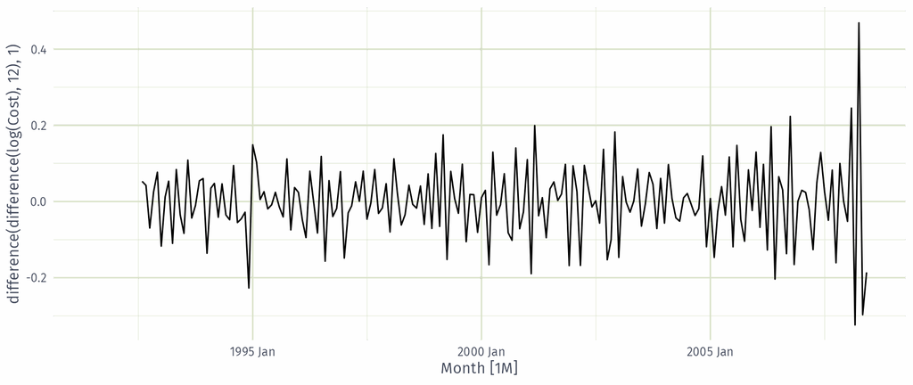

## Corticosteroid drug sales

```r
h02 |>
  model(arima = ARIMA(log(Cost))) |>
  report()
```

```
Series: Cost
Model: ARIMA(2,1,0)(0,1,1)[12]
Transformation: log(Cost)

Coefficients:
          ar1      ar2     sma1
      -0.8491  -0.4207  -0.6401
s.e.   0.0712   0.0714   0.0694

sigma^2 estimated as 0.004387:  log likelihood=245
AIC=-483   AICc=-483   BIC=-470
```

## Corticosteroid drug sales

```r
h02 |>
  model(arima = ARIMA(log(Cost))) |>
  forecast(h = "3 years") |>
  autoplot(h02)
```

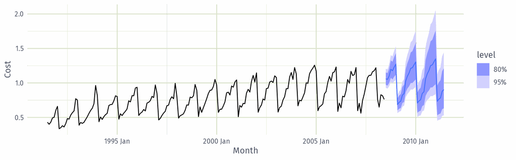

## Corticosteroid drug sales

```r
fit <- h02 |>
  model(best = ARIMA(log(Cost),
    stepwise = FALSE,
    approximation = FALSE,
    order_constraint = p + q + P + Q <= 9
  ))
report(fit)
```

```
Series: Cost
Model: ARIMA(4,1,1)(2,1,2)[12]
Transformation: log(Cost)

Coefficients:
          ar1    ar2    ar3     ar4     ma1   sar1    sar2    sma1   sma2
      -0.0425  0.210  0.202  -0.227  -0.742  0.621  -0.383  -1.202  0.496
s.e.   0.2167  0.181  0.114   0.081   0.207  0.242   0.118   0.249  0.213

sigma^2 estimated as 0.004049:  log likelihood=254
AIC=-489   AICc=-487   BIC=-456
```

## Corticosteroid drug sales

```r
fit |>
  forecast() |>
  autoplot(h02) +
  labs(y = "H02 Expenditure ($AUD)", x = "Year")
```

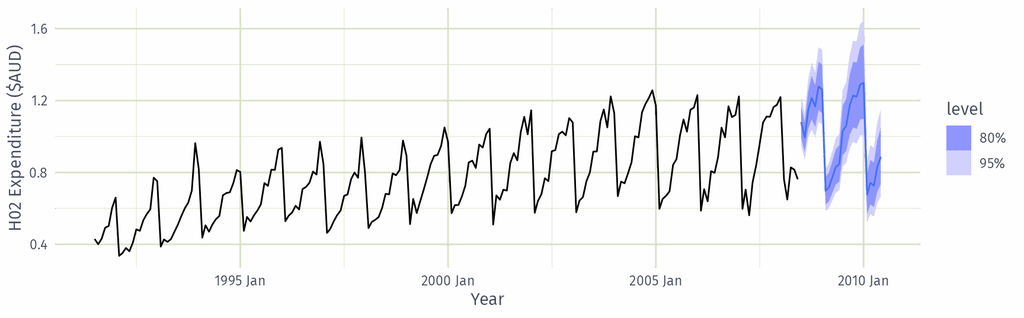

# Forecast ensembles

## Forecast ensembles

```r
train <- tourism |>
  filter(year(Quarter) <= 2014)
fit <- train |>
  model(
    ets = ETS(Trips),
    arima = ARIMA(Trips),
    snaive = SNAIVE(Trips)
  ) |>
  mutate(mixed = (ets + arima + snaive) / 3)
```

- Ensemble forecast `mixed` is a simple average of the three fitted models.
- `forecast()` will produce distributional forecasts taking into account the correlations between the forecast errors of the component models.

## Forecast ensembles

```r
fc <- fit |> forecast(h = "3 years")
fc |>
  filter(Region == "Snowy Mountains", Purpose == "Holiday") |>
  autoplot(tourism, level = NULL)
```

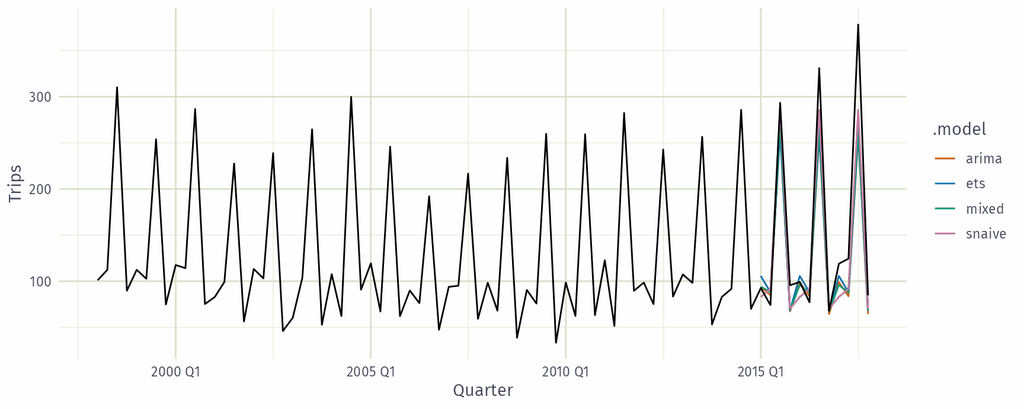